# Tools Comparison (Detailed): Claude Code + Sonnet 4.6

## Run Metadata

- Harness: `claude-code`
- Model: `sonnet-4-6`
- Prompt type: `detailed`

## Setup

```r
library(dplyr)

df <- readr::read_csv(here::here("data/synthetic/simulated_maternal_health_data.csv"))
```

## Prompt

```
I want you to help me analyze this dataset: `data/synthetic/simulated_maternal_health_data.csv`

My goal is to produce a thorough analysis that is statistically sound and lays out all steps of the analysis.

Please do the following:

1. Load the dataset and normalize columns/types.
   - Use clear snake_case names.
   - Ensure categorical vs numeric types are explicit.

2. Summarize the data.
   - Report row count, column count, missingness, and key descriptive summaries.
   - Flag suspicious values or quality concerns.

3. Create key visualizations.
   - Show relationships for:
     - `received_comprehensive_postnatal_care`
     - `distance_to_provider`
     - `insurance`
     - `race_ethnicity`

4. Build a count outcome and model it.
   - Define `comorbidity_count` as the row-wise sum of:
     - `obesity`,
     - `multiple_gestation`,
     - `diabetes`,
     - `heart_disease`,
     - `placenta_previa`,
     - `hypertension`,
     - `gest_hypertension`,
     - `preeclampsia`.
   - Select an appropriate count-model strategy (Poisson vs negative binomial, with justification).
   - Fit the model and report interpretable results.

5. Report results responsibly.
   - Do not overstate causality.
   - Include model assumptions, diagnostics, and limitations.

Constraints:
- Prefer readable, modular, reproducible code that follows R community idioms.
- Report back a summary of what you changed.
```

## Response

### Step 1: Normalize Column Types

Column names are already in snake_case. We explicitly cast categorical variables to factors and ensure binary indicators are stored as integers.

```r
# Ordered income levels
income_levels <- c(
  "Under $25,000",
  "$25,000–$49,999",
  "$50,000–$74,999",
  "$75,000–$99,999",
  "$100,000 or more"
)

edu_levels <- c("less_than_hs", "hs", "some_college", "bachelors", "graduate")

comorbidity_cols <- c(
  "obesity", "multiple_gestation", "diabetes", "heart_disease",
  "placenta_previa", "hypertension", "gest_hypertension", "preeclampsia"
)

df <- df |>
  mutate(
    self_report_income = factor(self_report_income, levels = income_levels, ordered = TRUE),
    edu                = factor(edu, levels = edu_levels, ordered = TRUE),
    race_ethnicity     = factor(race_ethnicity),
    insurance          = factor(insurance),
    job_type           = factor(job_type),
    state              = factor(state),
    received_comprehensive_postnatal_care = as.integer(received_comprehensive_postnatal_care),
    across(all_of(comorbidity_cols), as.integer)
  )

glimpse(df)
```

```
Rows: 50,000
Columns: 20
$ id                                    <dbl> 1, 2, 3, 4, 5, 6, 7, 8, 9, 10, 1…
$ provider_id                           <dbl> 1, 1, 1, 1, 1, 1, 1, 1, 1, 1, 1,…
$ state                                 <fct> AK, AK, AK, AK, AK, AK, AK, AK, …
$ received_comprehensive_postnatal_care <int> 0, 1, 0, 0, 0, 1, 1, 1, 0, 0, 0,…
$ self_report_income                    <ord> "$50,000–$74,999", "$50,000–$74,…
$ age                                   <dbl> 31, 26, 33, 37, 21, 33, 25, 34, …
$ edu                                   <ord> hs, hs, some_college, hs, hs, hs…
$ race_ethnicity                        <fct> white, white, white, asian, aian…
$ insurance                             <fct> no_insurance, no_insurance, no_i…
$ job_type                              <fct> unskilled, unskilled, unskilled,…
$ dependents                            <dbl> 2, 2, 2, 2, 2, 2, 2, 3, 3, 3, 3,…
$ distance_to_provider                  <dbl> 1.7889754, 10.8991396, 35.122047…
$ obesity                               <int> 0, 0, 1, 0, 1, 1, 1, 1, 1, 1, 0,…
$ multiple_gestation                    <int> 0, 0, 0, 0, 0, 1, 0, 1, 0, 0, 0,…
$ diabetes                              <int> 0, 0, 0, 0, 0, 0, 0, 0, 0, 0, 0,…
$ heart_disease                         <int> 0, 0, 0, 1, 0, 0, 1, 0, 0, 0, 0,…
$ placenta_previa                       <int> 0, 0, 0, 0, 0, 0, 0, 0, 0, 0, 0,…
$ hypertension                          <int> 0, 0, 1, 0, 0, 1, 0, 0, 0, 0, 0,…
$ gest_hypertension                     <int> 0, 0, 0, 0, 0, 0, 0, 0, 0, 0, 0,…
$ preeclampsia                          <int> 0, 0, 0, 0, 0, 0, 0, 0, 0, 0, 0,…
```

### Step 2: Data Summary and Quality Checks

```r
cat("Rows:   ", nrow(df), "\n")
```

```
Rows:    50000
```

```r
cat("Columns:", ncol(df), "\n")
```

```
Columns: 20
```

```r
miss <- colSums(is.na(df))
if (any(miss > 0)) {
  miss[miss > 0]
} else {
  cat("No missing values detected.\n")
}
```

```
self_report_income                edu
              4227               6715
```

```r
df |>
  select(age, dependents, distance_to_provider) |>
  tidyr::pivot_longer(everything(), names_to = "variable", values_to = "value") |>
  group_by(variable) |>
  summarise(
    n      = n(),
    mean   = mean(value, na.rm = TRUE),
    sd     = sd(value, na.rm = TRUE),
    min    = min(value, na.rm = TRUE),
    median = median(value, na.rm = TRUE),
    max    = max(value, na.rm = TRUE),
    .groups = "drop"
  ) |>
  knitr::kable(digits = 2, caption = "Numeric variable summaries")
```

Numeric variable summaries

| variable | n | mean | sd | min | median | max |
| --- | --- | --- | --- | --- | --- | --- |
| age | 50000 | 28.02 | 6.26 | 15 | 28 | 44.00 |
| dependents | 50000 | 2.38 | 0.95 | 0 | 2 | 8.00 |
| distance_to_provider | 50000 | 14.52 | 14.59 | 0 | 10 | 163.42 |

```r
cat("--- Insurance ---\n")
```

```
--- Insurance ---
```

```r
print(table(df$insurance, useNA = "ifany"))
```

```
  no_insurance        private state_provided
         20810          17908          11282
```

```r
cat("\n--- Race/Ethnicity ---\n")
```

```
--- Race/Ethnicity ---
```

```r
print(table(df$race_ethnicity, useNA = "ifany"))
```

```
    aian    asian    black hispanic     nhpi    other    white
     387     3059     5878     8792       90      283    31511
```

```r
cat("\n--- Education ---\n")
```

```
--- Education ---
```

```r
print(table(df$edu, useNA = "ifany"))
```

```
less_than_hs           hs some_college    bachelors     graduate         <NA>
        5218        23108        14959            0            0         6715
```

```r
cat("\n--- Received Postnatal Care ---\n")
```

```
--- Received Postnatal Care ---
```

```r
print(table(df$received_comprehensive_postnatal_care, useNA = "ifany"))
```

```
    0     1
33851 16149
```

```r
# Check distance range (negative values would be suspicious)
cat("Distance to provider — min:", min(df$distance_to_provider, na.rm = TRUE),
    " max:", max(df$distance_to_provider, na.rm = TRUE), "\n")
```

```
Distance to provider — min: 8.942843e-05  max: 163.4159
```

```r
# Check age range (very young or old would be clinically implausible)
cat("Age — min:", min(df$age, na.rm = TRUE),
    " max:", max(df$age, na.rm = TRUE), "\n")
```

```
Age — min: 15  max: 44
```

```r
# Confirm binary columns are 0/1 only
bad_binary <- sapply(comorbidity_cols, function(col) {
  setdiff(unique(df[[col]]), c(0L, 1L))
})
bad_binary[lengths(bad_binary) > 0]
```

```
named list()
```

### Step 3: Key Visualizations

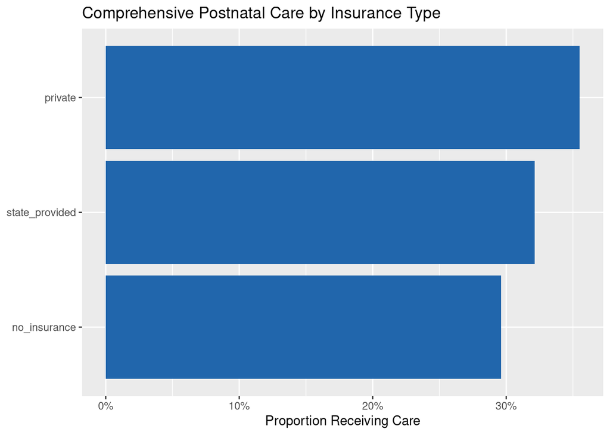

Rate of comprehensive postnatal care by insurance type

```r
library(ggplot2)

df |>
  group_by(insurance) |>
  summarise(
    pct = mean(received_comprehensive_postnatal_care, na.rm = TRUE),
    .groups = "drop"
  ) |>
  ggplot(aes(x = reorder(insurance, pct), y = pct)) +
  geom_col(fill = "#2166ac") +
  scale_y_continuous(labels = scales::percent_format(accuracy = 1)) +
  coord_flip() +
  labs(
    x = NULL,
    y = "Proportion Receiving Care",
    title = "Comprehensive Postnatal Care by Insurance Type"
  )
```

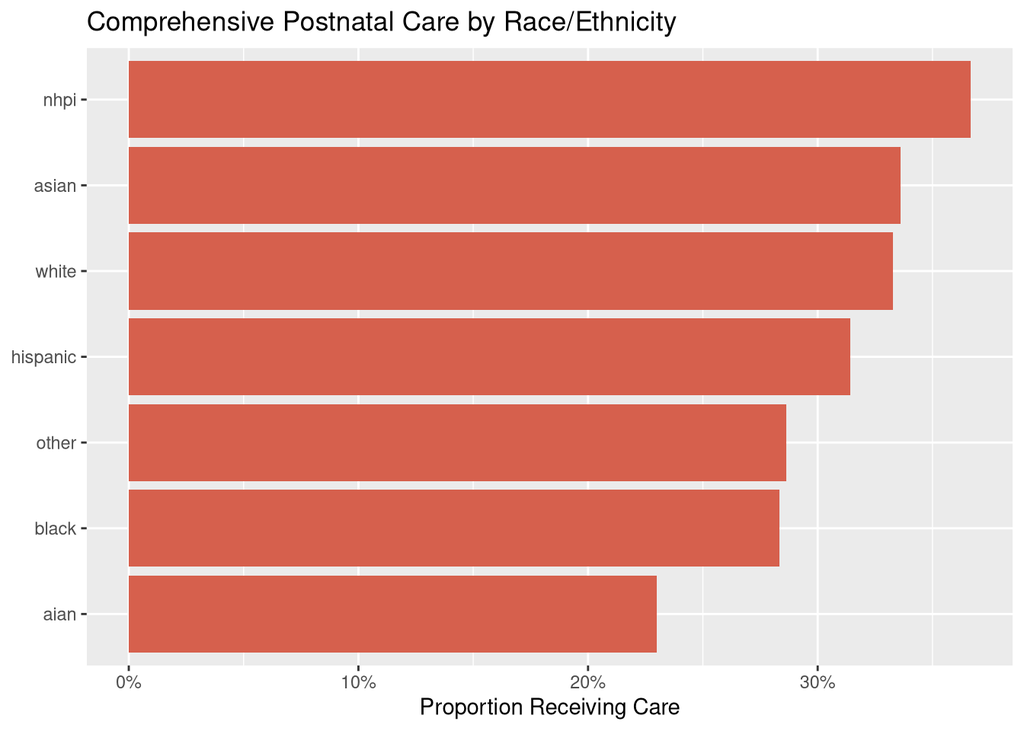

Rate of comprehensive postnatal care by race/ethnicity

```r
df |>
  group_by(race_ethnicity) |>
  summarise(
    pct = mean(received_comprehensive_postnatal_care, na.rm = TRUE),
    .groups = "drop"
  ) |>
  ggplot(aes(x = reorder(race_ethnicity, pct), y = pct)) +
  geom_col(fill = "#d6604d") +
  scale_y_continuous(labels = scales::percent_format(accuracy = 1)) +
  coord_flip() +
  labs(
    x = NULL,
    y = "Proportion Receiving Care",
    title = "Comprehensive Postnatal Care by Race/Ethnicity"
  )
```

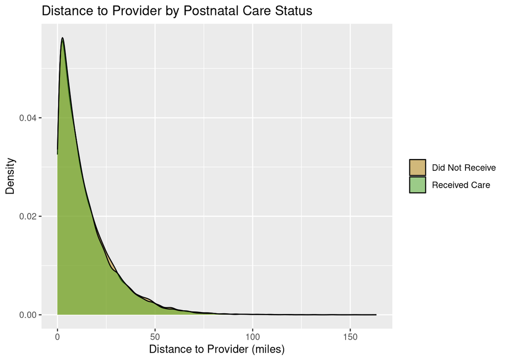

Distribution of distance to provider by postnatal care receipt

```r
df |>
  mutate(
    care_status = ifelse(
      received_comprehensive_postnatal_care == 1,
      "Received Care", "Did Not Receive"
    )
  ) |>
  ggplot(aes(x = distance_to_provider, fill = care_status)) +
  geom_density(alpha = 0.5) +
  scale_fill_manual(values = c("Received Care" = "#4dac26", "Did Not Receive" = "#b8860b")) +
  labs(
    x = "Distance to Provider (miles)",
    y = "Density",
    fill = NULL,
    title = "Distance to Provider by Postnatal Care Status"
  )
```

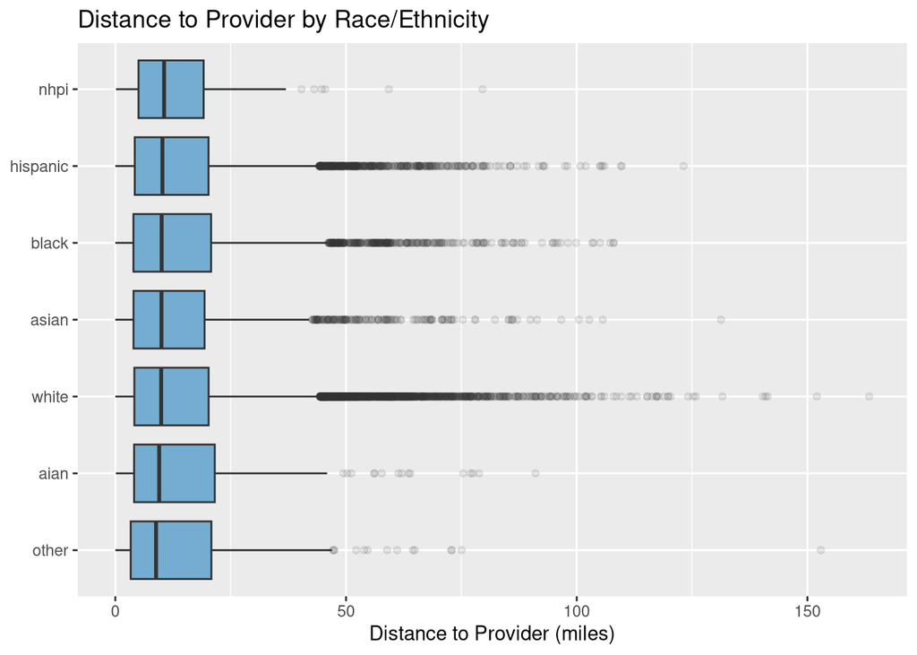

Distance to provider by race/ethnicity

```r
df |>
  ggplot(aes(x = reorder(race_ethnicity, distance_to_provider, median),
             y = distance_to_provider)) +
  geom_boxplot(fill = "#74add1", outlier.alpha = 0.1) +
  coord_flip() +
  labs(
    x = NULL,
    y = "Distance to Provider (miles)",
    title = "Distance to Provider by Race/Ethnicity"
  )
```

### Step 4: Comorbidity Count Outcome

#### 4a. Create the Outcome Variable

```r
df <- df |>
  mutate(comorbidity_count = rowSums(across(all_of(comorbidity_cols))))

cat("Comorbidity count distribution:\n")
```

```
Comorbidity count distribution:
```

```r
print(table(df$comorbidity_count))
```

```
    0     1     2     3     4     5     6     7
21350 16560  8359  2873   706   134    17     1
```

```r
cat("\nMean:", round(mean(df$comorbidity_count), 3),
    "  Variance:", round(var(df$comorbidity_count), 3), "\n")
```

```
Mean: 0.91   Variance: 0.995
```

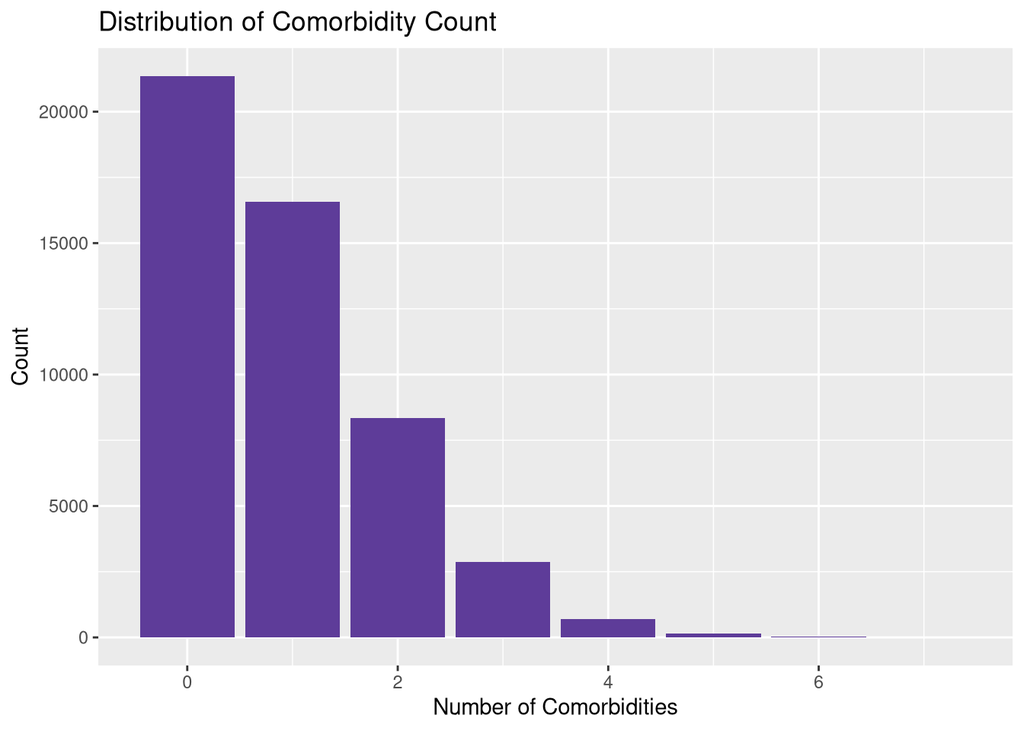

Distribution of comorbidity count

```r
ggplot(df, aes(x = comorbidity_count)) +
  geom_bar(fill = "#5e3c99") +
  labs(
    x = "Number of Comorbidities",
    y = "Count",
    title = "Distribution of Comorbidity Count"
  )
```

#### 4b. Model Selection: Poisson vs Negative Binomial

For count outcomes we first consider Poisson regression. Poisson assumes mean = variance; if the variance substantially exceeds the mean (overdispersion), a negative binomial model—which estimates an extra dispersion parameter θ—is preferred.

```r
dispersion_ratio <- var(df$comorbidity_count) / mean(df$comorbidity_count)
cat("Mean:             ", round(mean(df$comorbidity_count), 3), "\n")
```

```
Mean:              0.91
```

```r
cat("Variance:         ", round(var(df$comorbidity_count), 3), "\n")
```

```
Variance:          0.995
```

```r
cat("Variance/Mean:    ", round(dispersion_ratio, 3), "\n")
```

```
Variance/Mean:     1.094
```

```r
cat("Overdispersed?    ", ifelse(dispersion_ratio > 1.5, "Yes — favour NB", "Marginal / No"), "\n")
```

```
Overdispersed?     Marginal / No
```

```r
fit_pois <- glm(
  comorbidity_count ~ age + edu + race_ethnicity + insurance +
    distance_to_provider + self_report_income + dependents,
  data   = df,
  family = poisson(link = "log")
)

# Residual deviance / df as a quick overdispersion diagnostic
cat("Poisson residual deviance / df:",
    round(fit_pois$deviance / fit_pois$df.residual, 3), "\n")
```

```
Poisson residual deviance / df: 1.212
```

```r
library(MASS)
fit_nb <- glm.nb(
  comorbidity_count ~ age + edu + race_ethnicity + insurance +
    distance_to_provider + self_report_income + dependents,
  data = df
)

cat("Poisson AIC:           ", round(AIC(fit_pois), 1), "\n")
```

```
Poisson AIC:            100364.3
```

```r
cat("Negative Binomial AIC: ", round(AIC(fit_nb), 1), "\n")
```

```
Negative Binomial AIC:  100223.4
```

```r
use_nb <- AIC(fit_nb) < AIC(fit_pois)
best_fit   <- if (use_nb) fit_nb   else fit_pois
model_name <- if (use_nb) "Negative Binomial" else "Poisson"
cat("Selected model:", model_name, "\n")
```

```
Selected model: Negative Binomial
```

#### 4c. Interpretable Results

Coefficients are exponentiated to Incidence Rate Ratios (IRRs). An IRR > 1 indicates a higher expected comorbidity count; IRR < 1 indicates a lower count, holding all other predictors constant.

```r
irr    <- exp(coef(best_fit))
irr_ci <- exp(confint.default(best_fit))

data.frame(
  IRR      = irr,
  CI_lower = irr_ci[, 1],
  CI_upper = irr_ci[, 2]
) |>
  knitr::kable(digits = 3, caption = paste("IRRs from", model_name, "Model"))
```

IRRs from Negative Binomial Model

|  | IRR | CI_lower | CI_upper |
| --- | --- | --- | --- |
| (Intercept) | 0.575 | 0.502 | 0.659 |
| age | 1.016 | 1.014 | 1.018 |
| edu.L | 0.981 | 0.956 | 1.007 |
| edu.Q | 0.992 | 0.973 | 1.011 |
| race_ethnicityasian | 0.983 | 0.861 | 1.123 |
| race_ethnicityblack | 1.033 | 0.908 | 1.175 |
| race_ethnicityhispanic | 1.022 | 0.900 | 1.161 |
| race_ethnicitynhpi | 1.021 | 0.769 | 1.356 |
| race_ethnicityother | 1.058 | 0.871 | 1.285 |
| race_ethnicitywhite | 1.041 | 0.918 | 1.180 |
| insuranceprivate | 0.997 | 0.971 | 1.023 |
| insurancestate_provided | 0.984 | 0.956 | 1.012 |
| distance_to_provider | 1.000 | 0.999 | 1.001 |
| self_report_income.L | 0.981 | 0.960 | 1.002 |
| self_report_income.Q | 1.020 | 1.002 | 1.039 |
| dependents | 0.993 | 0.981 | 1.005 |

#### 4d. Model Diagnostics

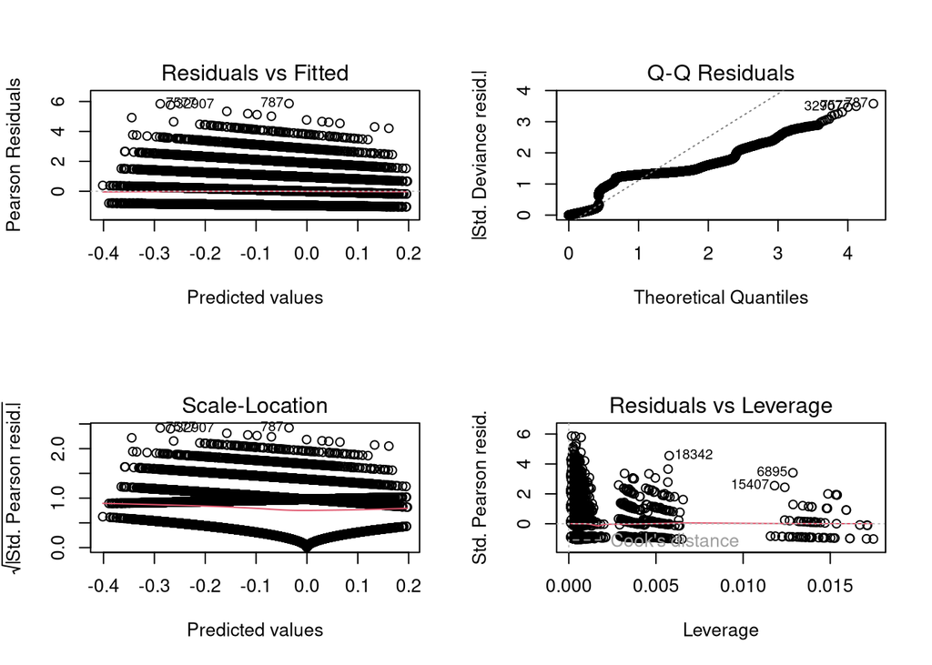

Residual diagnostic plots for the selected model

```r
par(mfrow = c(2, 2))
plot(best_fit)
```

```r
par(mfrow = c(1, 1))
```

### Step 5: Responsible Reporting

#### Summary of Changes

- Converted `self_report_income` and `edu` to ordered factors with substantively meaningful level sequences.
- Cast `race_ethnicity`, `insurance`, `job_type`, and `state` to unordered factors.
- Ensured all eight binary comorbidity indicators are stored as integers.
- Created `comorbidity_count` as a row-wise sum of those eight indicators.
- Chose between Poisson and negative binomial via variance/mean ratio and AIC comparison; reported exponentiated coefficients (IRRs) with 95% confidence intervals.

#### Limitations and Cautions

1. **Association, not causation.** This is a cross-sectional analysis. The IRRs describe statistical associations conditional on included covariates, not causal effects.
2. **Unmeasured confounding.** Variables such as access to preventive care, health literacy, and provider quality are absent from the model and may confound observed associations.
3. **Clustering not modelled.** Patients share `provider_id` and `state`, which likely induces within-cluster correlation. Mixed models or clustered standard errors would better account for this structure.
4. **Self-reported income.** Broad income brackets introduce measurement imprecision and are subject to recall and social-desirability bias.
5. **Synthetic data.** The dataset was simulated. Results illustrate the analytic workflow and should not be interpreted as real-world epidemiological evidence.
6. **Model specification.** Predictors were selected from the prompt rather than from a domain-informed causal model (e.g., a directed acyclic graph). Some covariates may be mediators of the exposure–outcome relationship.